# 07_read_histogram

## 07_read_histogram

#### Question

1. *S-ID.A: Summarize, represent, and interpret data on a single count or measurement variable. Use calculators, spreadsheets, and other technology as appropriate.*

   A spinner was made to model a [continuous triangular distribution](https://en.wikipedia.org/wiki/Triangular_distribution). It was spun 50 times; those locations are marked.

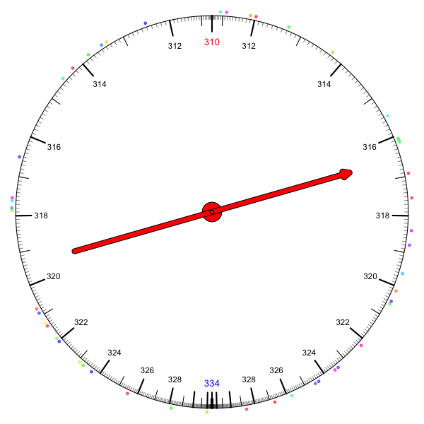

   The name “triangular distribution” comes from the probability density curve.

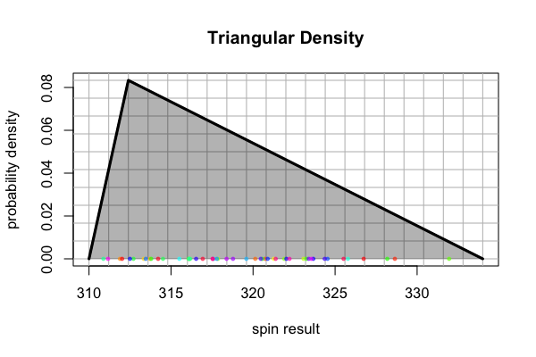

   Notice that because the spinner is continuous, it generates data like 321.729947 and 325.0745512. Of course, a human would probably round to the nearest tenth or so.

### Actual question

   The 50 spins were used to generate a histogram.

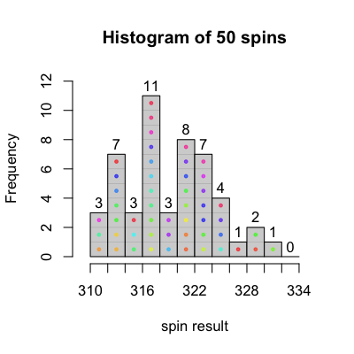

   - How many spins were less than 316?
     - $\#(x<316) =$
   - What proportion of spins were less than 316?
     - $\mathrm{proportion}(x<316) =$
   - How many spins were more than 318?
     - $\#(x>318) =$
   - What proportion of spins were more than 318?
     - $\mathrm{proportion}(x>318) =$
   - How many spins were between 314 and 326?
     - $\#(314<x<326) =$
   - What proportion of spins were between 314 and 326?
     - $\mathrm{proportion}(314<x<326) =$

#### Question

2. *S-ID.A: Summarize, represent, and interpret data on a single count or measurement variable. Use calculators, spreadsheets, and other technology as appropriate.*

   A spinner was made to model a [continuous triangular distribution](https://en.wikipedia.org/wiki/Triangular_distribution). It was spun 50 times; those locations are marked.

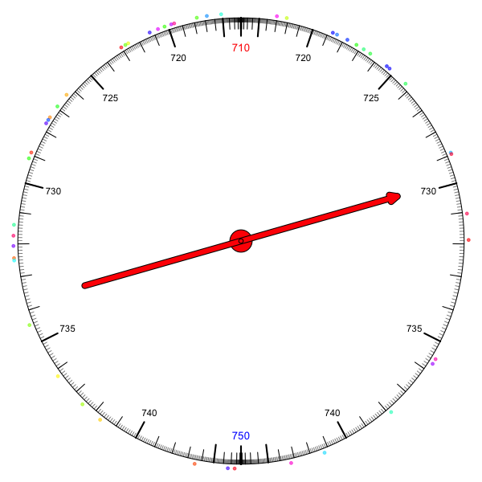

   The name “triangular distribution” comes from the probability density curve.

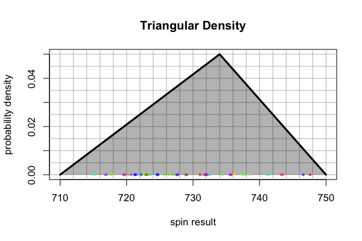

   Notice that because the spinner is continuous, it generates data like 735.8279015 and 738.5917768. Of course, a human would probably round to the nearest tenth or so.

### Actual question

   The 50 spins were used to generate a histogram.

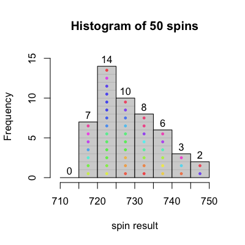

   - How many spins were less than 725?
     - $\#(x<725) =$
   - What proportion of spins were less than 725?
     - $\mathrm{proportion}(x<725) =$
   - How many spins were more than 730?
     - $\#(x>730) =$
   - What proportion of spins were more than 730?
     - $\mathrm{proportion}(x>730) =$
   - How many spins were between 720 and 740?
     - $\#(720<x<740) =$
   - What proportion of spins were between 720 and 740?
     - $\mathrm{proportion}(720<x<740) =$

#### Question

3. *S-ID.A: Summarize, represent, and interpret data on a single count or measurement variable. Use calculators, spreadsheets, and other technology as appropriate.*

   A spinner was made to model a [continuous triangular distribution](https://en.wikipedia.org/wiki/Triangular_distribution). It was spun 50 times; those locations are marked.

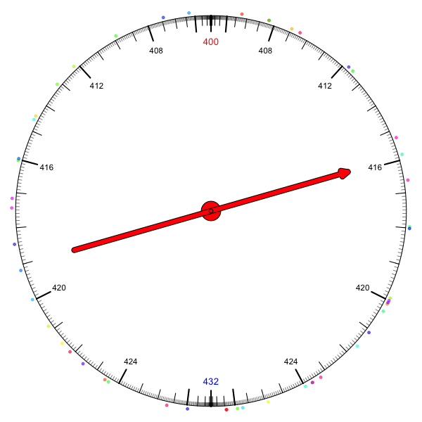

   The name “triangular distribution” comes from the probability density curve.

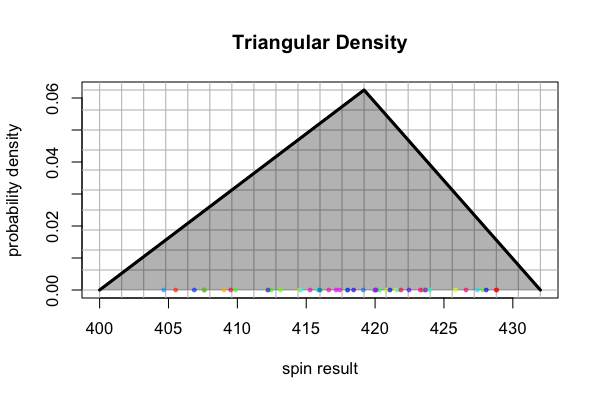

   Notice that because the spinner is continuous, it generates data like 419.8942532 and 418.6319499. Of course, a human would probably round to the nearest tenth or so.

### Actual question

   The 50 spins were used to generate a histogram.

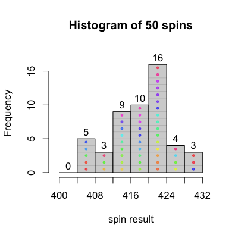

   - How many spins were less than 412?
     - $\#(x<412) =$
   - What proportion of spins were less than 412?
     - $\mathrm{proportion}(x<412) =$
   - How many spins were more than 416?
     - $\#(x>416) =$
   - What proportion of spins were more than 416?
     - $\mathrm{proportion}(x>416) =$
   - How many spins were between 408 and 420?
     - $\#(408<x<420) =$
   - What proportion of spins were between 408 and 420?
     - $\mathrm{proportion}(408<x<420) =$

#### Question

4. *S-ID.A: Summarize, represent, and interpret data on a single count or measurement variable. Use calculators, spreadsheets, and other technology as appropriate.*

   A spinner was made to model a [continuous triangular distribution](https://en.wikipedia.org/wiki/Triangular_distribution). It was spun 50 times; those locations are marked.

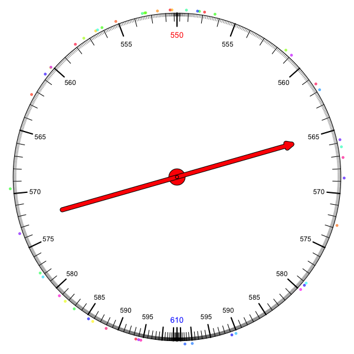

   The name “triangular distribution” comes from the probability density curve.

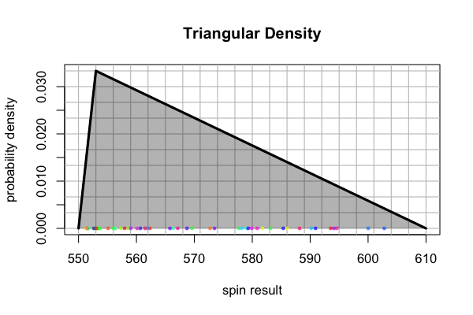

   Notice that because the spinner is continuous, it generates data like 559.5924609 and 564.1660119. Of course, a human would probably round to the nearest tenth or so.

### Actual question

   The 50 spins were used to generate a histogram.

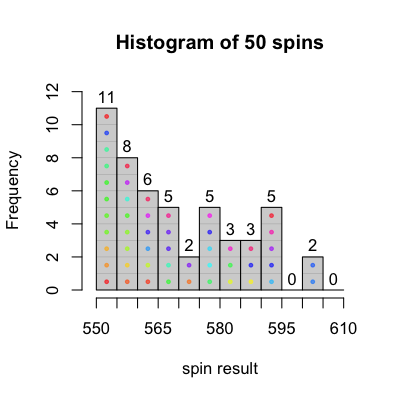

   - How many spins were less than 580?
     - $\#(x<580) =$
   - What proportion of spins were less than 580?
     - $\mathrm{proportion}(x<580) =$
   - How many spins were more than 590?
     - $\#(x>590) =$
   - What proportion of spins were more than 590?
     - $\mathrm{proportion}(x>590) =$
   - How many spins were between 575 and 600?
     - $\#(575<x<600) =$
   - What proportion of spins were between 575 and 600?
     - $\mathrm{proportion}(575<x<600) =$

#### Question

5. *S-ID.A: Summarize, represent, and interpret data on a single count or measurement variable. Use calculators, spreadsheets, and other technology as appropriate.*

   A spinner was made to model a [continuous triangular distribution](https://en.wikipedia.org/wiki/Triangular_distribution). It was spun 50 times; those locations are marked.

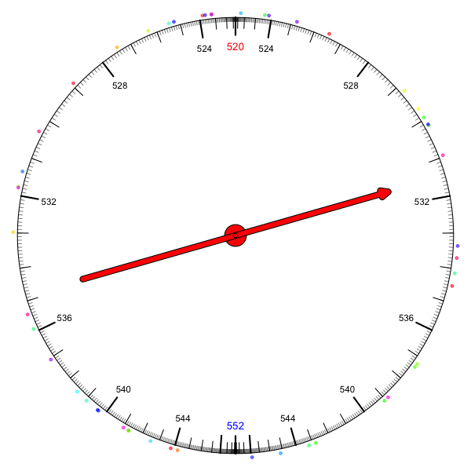

   The name “triangular distribution” comes from the probability density curve.

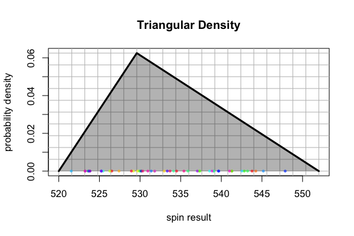

   Notice that because the spinner is continuous, it generates data like 529.3615819 and 541.980132. Of course, a human would probably round to the nearest tenth or so.

### Actual question

   The 50 spins were used to generate a histogram.

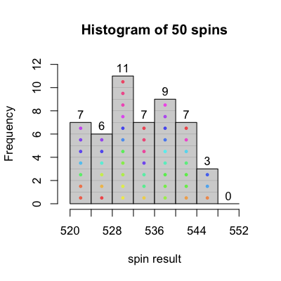

   - How many spins were less than 536?
     - $\#(x<536) =$
   - What proportion of spins were less than 536?
     - $\mathrm{proportion}(x<536) =$
   - How many spins were more than 528?
     - $\#(x>528) =$
   - What proportion of spins were more than 528?
     - $\mathrm{proportion}(x>528) =$
   - How many spins were between 524 and 540?
     - $\#(524<x<540) =$
   - What proportion of spins were between 524 and 540?
     - $\mathrm{proportion}(524<x<540) =$

#### Question

6. *S-ID.A: Summarize, represent, and interpret data on a single count or measurement variable. Use calculators, spreadsheets, and other technology as appropriate.*

   A spinner was made to model a [continuous triangular distribution](https://en.wikipedia.org/wiki/Triangular_distribution). It was spun 50 times; those locations are marked.

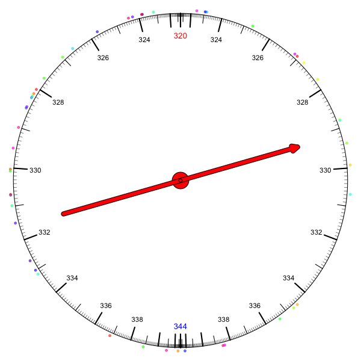

   The name “triangular distribution” comes from the probability density curve.

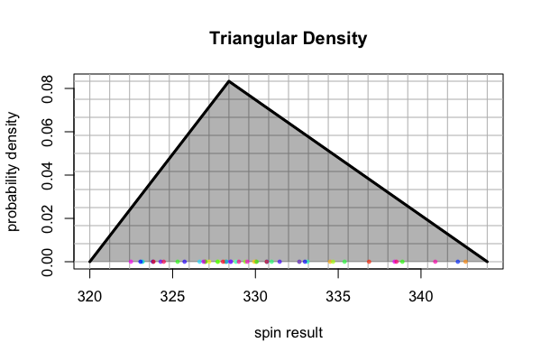

   Notice that because the spinner is continuous, it generates data like 333.7525061 and 330.7309498. Of course, a human would probably round to the nearest tenth or so.

### Actual question

   The 50 spins were used to generate a histogram.

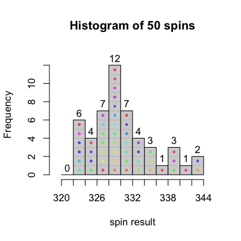

   - How many spins were less than 330?
     - $\#(x<330) =$
   - What proportion of spins were less than 330?
     - $\mathrm{proportion}(x<330) =$
   - How many spins were more than 328?
     - $\#(x>328) =$
   - What proportion of spins were more than 328?
     - $\mathrm{proportion}(x>328) =$
   - How many spins were between 324 and 334?
     - $\#(324<x<334) =$
   - What proportion of spins were between 324 and 334?
     - $\mathrm{proportion}(324<x<334) =$

#### Question

7. *S-ID.A: Summarize, represent, and interpret data on a single count or measurement variable. Use calculators, spreadsheets, and other technology as appropriate.*

   A spinner was made to model a [continuous triangular distribution](https://en.wikipedia.org/wiki/Triangular_distribution). It was spun 50 times; those locations are marked.

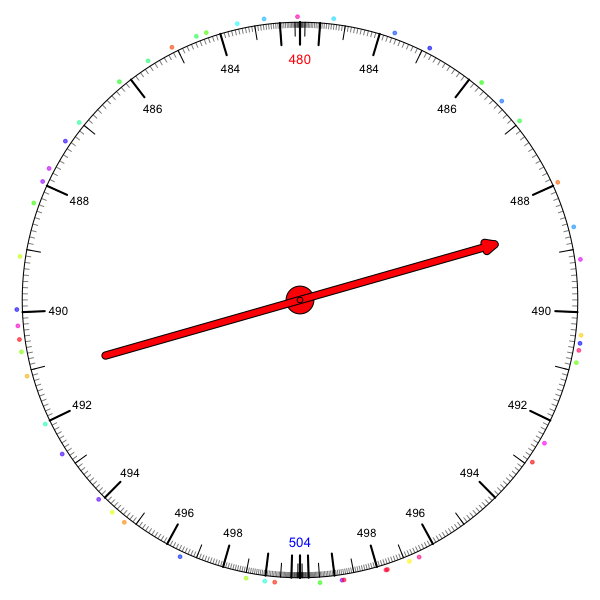

   The name “triangular distribution” comes from the probability density curve.

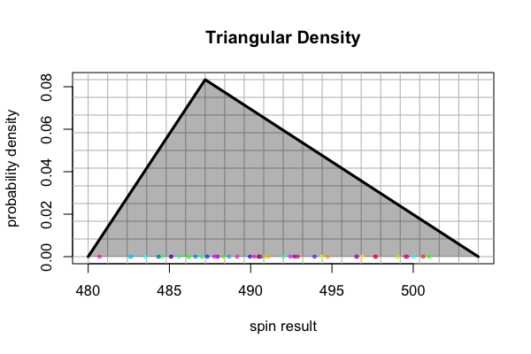

   Notice that because the spinner is continuous, it generates data like 485.3445074 and 492.722978. Of course, a human would probably round to the nearest tenth or so.

### Actual question

   The 50 spins were used to generate a histogram.

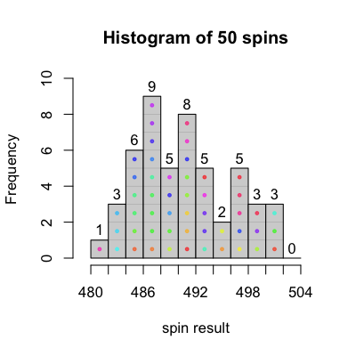

   - How many spins were less than 488?
     - $\#(x<488) =$
   - What proportion of spins were less than 488?
     - $\mathrm{proportion}(x<488) =$
   - How many spins were more than 494?
     - $\#(x>494) =$
   - What proportion of spins were more than 494?
     - $\mathrm{proportion}(x>494) =$
   - How many spins were between 496 and 502?
     - $\#(496<x<502) =$
   - What proportion of spins were between 496 and 502?
     - $\mathrm{proportion}(496<x<502) =$

#### Question

8. *S-ID.A: Summarize, represent, and interpret data on a single count or measurement variable. Use calculators, spreadsheets, and other technology as appropriate.*

   A spinner was made to model a [continuous triangular distribution](https://en.wikipedia.org/wiki/Triangular_distribution). It was spun 50 times; those locations are marked.

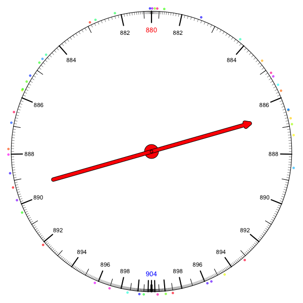

   The name “triangular distribution” comes from the probability density curve.

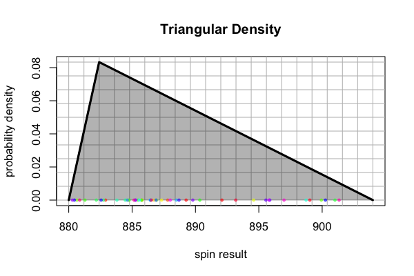

   Notice that because the spinner is continuous, it generates data like 892.9444245 and 886.5069063. Of course, a human would probably round to the nearest tenth or so.

### Actual question

   The 50 spins were used to generate a histogram.

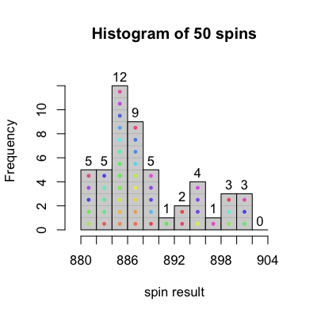

   - How many spins were less than 892?
     - $\#(x<892) =$
   - What proportion of spins were less than 892?
     - $\mathrm{proportion}(x<892) =$
   - How many spins were more than 896?
     - $\#(x>896) =$
   - What proportion of spins were more than 896?
     - $\mathrm{proportion}(x>896) =$
   - How many spins were between 894 and 902?
     - $\#(894<x<902) =$
   - What proportion of spins were between 894 and 902?
     - $\mathrm{proportion}(894<x<902) =$